# Fourier Time Series

# *Methods of Power Spectral Estimation*

## 1. Discrete Fourier Transform

## 2. Periodogram

## 3. Fast Fourier Transform

## 4. Blackman-Tuckey Method

Blackman and Tuckey prescribed some techniques to analyze a continuous spectrum that was biased by the presence of sidelobes of strong peaks. Blackman-Tuckey(BT) method was developed before 1958, prior to the FFT(Fast Fourier Transform) method. A discrete fourier transform of N points would require the calculation of $N^2$ sines and cosines. With the slower computer in the pre-FFT days, BT method has reduced the time by reducing the size of the dataset by a factor of the lag in the autocorrelation calculation. BT method is based on a fundamental theorem of Fourier transform that the Fourier transform of a correlation is equal to the product of the Fourier transforms. The correlation of two functions $g(t)$ and $h(t)$ is given by the first equation below.

$C(\tau)=f\otimes g= \int_{-\infty}^{\infty} g(t) f(t+\tau) d\tau$ $FT(f\otimes g) = FT(f) FT(g)$

When f = g, it is called Wiener-Khintchine theorem. Here, P is the spectral power.

$FT(f\otimes f) = |FT(f)|^2 = P$

The algorithm calculates partial autocorrelation function, defined by

$A_{BT}(\tau) = \int_{0}^{N/l} f(t+\tau)f(t) dt$

Here, N is the length of the data set but we integrate only upto $N/l$. $l$ is associated with the lag. When $l=3$ (recommended by Blackman and Tuckey) is used, we say that “a lag of 1/3” is used. If $N=1$, then it is basically the full autocorrelation function and gives the same answer as the ordinary periodogram.

## 5. Tapers

Fourier transform is defined for a function on a finite interval and the function needs to be periodic. But with the real data set, this requirment is not met as the data end suddenly at t=0 and t=T and can have discontinuities. This discontinuity introduces distortions (known as Gibbs phenomenon) in fourier transform and generates false high frequency in the spectrum. Tapering (using data window) is used to reduce these artificial presence. The data $y=f(t)$ is multiplied by a taper function $g(t)$ which is a simple, slowly varying function, often going towards zero near the edges. Some of the popular tapers are:

- Sine taper $g(t) = sin(\pi t/T)$ - Hanning (offset cosine) taper $g(t) = \frac{1}{2}(1-cos(2\pi t/T))$ - Hamming taper $g(t) =$ 0.54 - 0.46 $cos$(2$\pi$ t/T) - Parzen or Bartlett (triangle) window $g(t) = 1 - (t - T/2)/(T/2)$ - Welch (parabolic) window $g(t) = 1 - (t - T/2)^2/(T/2)^2$ - Daniell (untapered or rectangular) window $g(t) = 1$

The frequency resolution in the spectrum of the tapered data is degraded. If the primary interest is the resolution of peaks, then the untapered periodogram is superior. However, tapering significantly reduces the sidelobes and also the bias applied to other nearby peaks by the sidelobes of a strong peak. Because, the taper functions are broad and slowly varying and their fourier transform FT(g) are narrow. The effect of tapering the data is to convolve the fourier transform of the data with the narrow fourier transform of the taper function which amounts to smoothing the spectral values.

$FT(fg) = FT(f) * FT(g)$

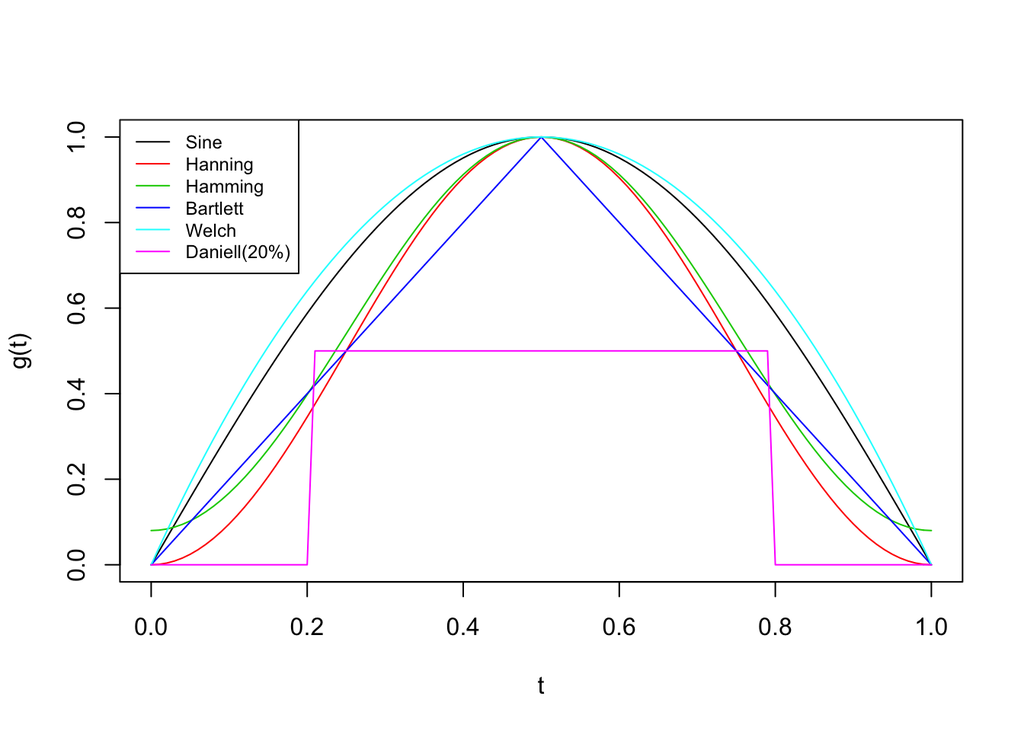

```r
  # Sine taper
  t <- seq(0,1, by=0.01)
  T <- 1
  g <- sin(pi * t * T)
  plot(t, g, t='l', col=1, ylab='g(t)')

  # Hanning (offset cosine) taper
  g2 <- 1/2 * (1-cos(2*pi*t/T))
  lines(t, g2, t='l', col=2)

  # Hamming
  g3 <- 0.54 - 0.46 * cos(2*pi*t/T)
  lines(t, g3, t='l', col=3)

  # Parzen or Bartlett (triangle) window
  g4 <- ifelse(t>0.5, 1 - (t-T/2)/(T/2), 2*t)
  lines(t, g4, t='l', col=4)

  # Welch (parabolic) window
  g5 <- 1 - (t-T/2)^2/(T/2)^2
  lines(t, g5, t='l', col=5)

  # Daniell window
  g6 <- rep(0.5, length(t))
  g6 <- ifelse(t <= 0.2, 0, g6)
  g6 <- ifelse(t >= 0.8, 0, g6)
  lines(t, g6, t='l', col=6)

  legnd = c('Sine', 'Hanning', 'Hamming', 'Bartlett', 'Welch', 'Daniell(20%)')
  legend('topleft', legend=legnd ,col=1:6, lty=1, cex=0.75)
```

## 5.1 Multitaper Analysis

## 6. Lomb-Scargle Periodogram

The classic periodogram requires evenly spaced data, but we frequently encounter with unevenly spaced data in paleoclimatic research. Lomb and Scargle showed that if the cosine and sine coefficients are normalized separately, then the classic periodogram can be used with unevenly spaced data. If we have a data set $(t_k, y_k)$, we first calculate the mean and variance:

$\bar{y} = \frac{1}{N} \sum_{k=1}^{N}y_k$ $\sigma^2 = \frac{1}{N-1} \sum_{k=1}^{N}[y_k - \bar{y}]^2$

For every frequency f, a time constant $\tau$ is defined by

$\tau = \frac{ \sum_{k=1}^{N}sin(4\pi f t_k)}{\sum_{k=1}^{N}cos(4\pi f t_k)}$

Then the Lomb-Scargle periodogram of the spectral power $P(f)$ at frequency f is given by

$P(f) = \frac{1}{2\sigma^2}\frac{ \sum_{k=1}^{N}(y_k - \bar{y} ) [cos(2\pi f (t_k-\tau))]^2}{\sum_{k=1}^{N}cos^2(2\pi f (t_k-\tau))} + \frac{ \sum_{k=1}^{N}(y_k - \bar{y} ) [sin(2\pi f (t_k-\tau))]^2}{\sum_{k=1}^{N}cos^2(2\pi f (t_k-\tau))}$

With evenly spaced data, two signals of different frequencies can have identical values which is known as Aliasing. That is why the classic periodogram is usually shown with the frequency range from 0 to 0.5, as the rest is a mirrored version. But with Lomb-Scargle periodogram, the aliasing effect can be significantly reduced.

## 7. Maximum Likelihood Analysis

## 8. Maximum Entropy Method

## 9. Cross Spectrum and Coherency

## 10. Bispectra

## 11. Monte Carlo Simulation

# 1. Oxygen Isotopes

# 2. Deuterium - Temperature Proxy

# 3. Carbon-13

# 4. Vostok

# 5. Atmospheric $\delta^{18}O$ and Dole Effect

# 6. $\delta^{18}O$ / $CO_2$ Mystery

# 7. Sea Floor Records

# 8. Terrestrial Records